# Forschungspraktikum 1+2: Computational Social Science

Tutorial 11: Working with GitHub

Dr. Christian Czymara

In this tutorial, we will learn how to set up GitHub within RStudio.

## 0. Getting Started

This time, we will not need particular packages. However, we will work with Git, so you need to install it using [this link](https://git-scm.com/downloads). You may also want to install [GitHub Desktop](https://github.com/apps/desktop) (although it’s not used in this tutorial).

## 1. Setting up GitHub

Go to [GitHub](https://github.com/) and create a GitHub account if you don’t have one yet (otherwise log in).

## 2. Creating a Repository

Create a [new repository](https://github.com/new). Name it `FoPra_CSS_session_11` and add a description if you like. Make it public and initialize it with a README file.

## 3. Setting up the Repository on Your Computer

### a) Clone the Repository in a New R Project

To clone the repository to your computer in RStudio; click on `File` -> `New Project` -> `Version Control` -> `Git` and pasting the URL of the repository.

### b) Create a New R Script

Within the repository folder on you computer, create a new R script. Name it `Rtwork.R`. Add the [following code](https://r-graph-gallery.com/137-spring-shapes-data-art.html) to the script:

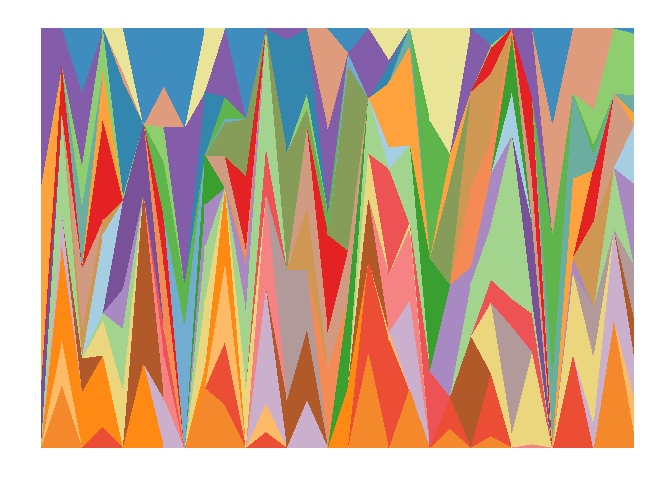

```r
set.seed(345)
library(ggplot2)
library(RColorBrewer)
ngroup=30
names=paste("G_",seq(1,ngroup),sep="")
DAT=data.frame()

for(i in seq(1:30)){
    data=data.frame( matrix(0, ngroup , 3))
    data[,1]=i
    data[,2]=sample(names, nrow(data))
    data[,3]=prop.table(sample( c(rep(0,100),c(1:ngroup)) ,nrow(data)))
    DAT=rbind(DAT,data)
    }
colnames(DAT)=c("Year","Group","Value")
DAT=DAT[order( DAT$Year, DAT$Group) , ]


coul = brewer.pal(12, "Paired")
coul = colorRampPalette(coul)(ngroup)
coul=coul[sample(c(1:length(coul)) , size=length(coul) ) ]

ggplot(DAT, aes(x=Year, y=Value, fill=Group )) +
    geom_area(alpha=1  )+
    theme_bw() +
    #scale_fill_brewer(colour="red", breaks=rev(levels(DAT$Group)))+
    scale_fill_manual(values = coul)+
     theme(
        text = element_blank(),
        line = element_blank(),
        title = element_blank(),
        legend.position="none",
        panel.border = element_blank(),
        panel.background = element_blank())
```

### c) Commit Changes and Push to GitHub

Save the script and commit the changes in RStudio. Then push the changes to GitHub. Congratulations, you just created your first repository on GitHub!

**Please remember to share your term paper code via GitHub.**